# Affective theory of mind impairments underlying callous-unemotional traits and the role of cognitive control: A pilot study

Drew E. Winters

08 February, 2022

# 1 Loading packages

```r
library(lmerTest) ## for MLM with p values
library(ggplot2)  ## plotting
library(forcats)  ## to adjust for plot values
library(dplyr)    ## data manipulation
library(lmtest)   ## for likelihood ratio tests
library(car)      ## re-coding and Durban Watson test
library(lavaan)   ## ML estimation
library(olsrr)    ## Multicollinearity
library(MKinfer)  ## Bootstrapped T tests
```

# 2 Demographics

## 2.1 Age

```r
psych::describe(T2_dat$age)
```

|  | vars | n | mean | sd | median | trimmed | mad | min | max | range | skew | kurtosis | se |
| --- | --- | --- | --- | --- | --- | --- | --- | --- | --- | --- | --- | --- | --- |
| X1 | 1 | 81 | 12.88889 | 0.7582875 | 13 | 12.86154 | 1.4826 | 12 | 14 | 2 | 0.182473 | -1.265745 | 0.08425417 |

## 2.2 Sex

```r
a<-rbind(table(T2_dat$sex_male),round((table(T2_dat$sex_male)/sum(table(T2_dat$sex_male))*100),0))
colnames(a)<-c('female','male')
rownames(a)<-c('n','%')
a
```

```
##   female male
## n     42   39
## %     52   48
```

## 2.3 High to normative CU

```r
a<-rbind(table(T2_dat$cu_group_9split),round((table(T2_dat$cu_group_9split)/sum(table(T2_dat$cu_group_9split))*100),0))
colnames(a)<-c('low_CU','hi_CU')
rownames(a)<-c('n','%')
a
```

```
##   low_CU hi_CU
## n     35    46
## %     43    57
```

## 2.4 calculating clinical cutoffs

### 2.4.1 CU traits

```r
clin<-ifelse(ifelse(T2_dat$sex_male==0 & T2_dat$age<=14 & T2_dat$icu_total >= 31, 1,0)+ifelse(T2_dat$sex_male==0 & T2_dat$age>=15 & T2_dat$icu_total >= 34, 1,0) + ifelse(T2_dat$sex_male==1 & T2_dat$age<=14 & T2_dat$icu_total >= 36, 1,0)+ifelse(T2_dat$sex_male==1 & T2_dat$age>=15 & T2_dat$icu_total >= 40, 1,0),1,0)


clindat<-data.frame(rbind(as.character(table(clin)),round(((table(clin)/NROW(clin))*100),2)))
colnames(clindat)<- c("non-clinical", "clinical")
rownames(clindat)<- c("n", "%")
clindat
```

|  | non-clinical | clinical |
| --- | --- | --- |
| n | 55 | 26 |
| % | 67.9 | 32.1 |

### 2.4.2 SDQ CD

```r
sum(T2_dat$sdq_cd)
```

```
## [1] 6
```

```r
sum(T2_dat$sdq_cd)/nrow(T2_dat)*100
```

```
## [1] 7.407407
```

## 2.5 Race & Ethnicity

### 2.5.1 Multiple races

```r
over_1_race<-which((T2_dat$race_Asian)+(T2_dat$race_Indian)+(T2_dat$race_Black)+
  (T2_dat$race_PacificIsland)+(T2_dat$race_White)+
  (T2_dat$race_other)>1)
    ### # of participants who selected more than one race
length(over_1_race)
```

```
## [1] 8
```

```r
round(length(over_1_race)/NROW(T2_dat)*100,2)
```

```
## [1] 9.88
```

### 2.5.2 Describing all races

```r
race<-(1*T2_dat$race_Asian)+(2*T2_dat$race_Indian)+(3*T2_dat$race_Black)+
  (5*T2_dat$race_PacificIsland)+(6*T2_dat$race_White)+
  (7*T2_dat$race_other)

    ## race # and proportion
a<-rbind(as.character(table(race)),round((table(race)/sum(table(race))*100),2))
rownames(a)<-c("n","%")
a
```

```
##   0      1      2      3       6       7
## n "8"    "1"    "1"    "14"    "56"    "1"
## % "9.88" "1.23" "1.23" "17.28" "69.14" "1.23"
```

### 2.5.3 Ethnicity

```r
a<-rbind(as.character(table(T2_dat$race_Latino)),round((table(T2_dat$race_Latino)/sum(table(T2_dat$race_Latino))*100),3))
colnames(a) <-c("non-latinx", "latinx")
rownames(a) <- c("n","%")
a
```

```
##   non-latinx latinx
## n "68"       "13"
## % "83.951"   "16.049"
```

## 2.6 Descriptives table

### 2.6.1 continuous descriptives

```r
psych::describe(T2_dat %>% select("icu_total",
                                  "sdq_total_cd",
                                  "load2_max",
                                  "mie1_c",
                                  "mie2_c","age"))
```

|  | vars | n | mean | sd | median | trimmed | mad | min | max | range | skew | kurtosis | se |
| --- | --- | --- | --- | --- | --- | --- | --- | --- | --- | --- | --- | --- | --- |
| icu_total | 1 | 81 | 30.234568 | 6.6825736 | 30 | 29.75385 | 5.9304 | 18 | 48 | 30 | 0.5699084 | -0.03718048 | 0.74250818 |
| sdq_total_cd | 2 | 81 | 1.506173 | 1.7111652 | 1 | 1.20000 | 1.4826 | 0 | 8 | 8 | 1.5345418 | 2.48999603 | 0.19012947 |
| load2_max | 3 | 81 | 1068.518519 | 525.9185087 | 1300 | 1114.61538 | 444.7800 | 150 | 1600 | 1450 | -0.6188207 | -1.24580645 | 58.43538985 |
| mie1_c | 4 | 81 | 19.641975 | 3.2837046 | 20 | 19.81538 | 2.9652 | 10 | 27 | 17 | -0.5414137 | 0.61243144 | 0.36485607 |
| mie2_c | 5 | 81 | 18.827160 | 4.5901801 | 20 | 19.29231 | 4.4478 | 5 | 26 | 21 | -0.9670335 | 0.72127993 | 0.51002001 |
| age | 6 | 81 | 12.888889 | 0.7582875 | 13 | 12.86154 | 1.4826 | 12 | 14 | 2 | 0.1824730 | -1.26574457 | 0.08425417 |

### 2.6.2 dichotomous descriptives

```r
data.frame(rbind(as.character(table(T2_dat$bad_resp_2)), round(table(T2_dat$bad_resp_2)/(sum(table(T2_dat$bad_resp_2))/100),3)), row.names = c("bad_resp n","bad_resp %"))
```

|  | X0 | X1 |
| --- | --- | --- |
| bad_resp n | 66 | 15 |
| bad_resp % | 81.481 | 18.519 |

```r
data.frame(rbind(as.character(table(T2_dat$sex_male)), round(table(T2_dat$sex_male)/(sum(table(T2_dat$sex_male))/100),3)), row.names = c("sex_male n","sex_male %"))
```

|  | X0 | X1 |
| --- | --- | --- |
| sex_male n | 42 | 39 |
| sex_male % | 51.852 | 48.148 |

```r
data.frame(rbind(as.character(table(T2_dat$race_White)), round(table(T2_dat$race_White)/(sum(table(T2_dat$race_White))/100),3)), row.names = c("race_White n","race_White %"))
```

|  | X0 | X1 |
| --- | --- | --- |
| race_White n | 25 | 56 |
| race_White % | 30.864 | 69.136 |

### 2.6.3 correlations

```r
data.frame(cor(T2_dat %>% select("icu_total",
                                 "sdq_total_cd",
                                 "load2_max",
                                 "mie1_c",
                                 "mie2_c",
                                 "age",
                                 "sex_male",
                                 "race_White")))
```

|  | icu_total | sdq_total_cd | load2_max | mie1_c | mie2_c | age | sex_male | race_White |
| --- | --- | --- | --- | --- | --- | --- | --- | --- |
| icu_total | 1.00000000 | 0.56010415 | -0.19189080 | -0.25759081 | -0.231349045 | 0.02494200 | 0.07757851 | 0.023599257 |
| sdq_total_cd | 0.56010415 | 1.00000000 | -0.12027638 | -0.12751687 | -0.187651556 | -0.03318206 | 0.17812007 | 0.183159112 |
| load2_max | -0.19189080 | -0.12027638 | 1.00000000 | 0.12838330 | 0.194740650 | 0.24814184 | -0.09323478 | -0.042801572 |
| mie1_c | -0.25759081 | -0.12751687 | 0.12838330 | 1.00000000 | 0.635240203 | 0.03904519 | -0.16685133 | -0.048733930 |
| mie2_c | -0.23134904 | -0.18765156 | 0.19474065 | 0.63524020 | 1.000000000 | 0.08419500 | -0.11514868 | -0.001880581 |
| age | 0.02494200 | -0.03318206 | 0.24814184 | 0.03904519 | 0.084195002 | 1.00000000 | 0.04371650 | -0.098513801 |
| sex_male | 0.07757851 | 0.17812007 | -0.09323478 | -0.16685133 | -0.115148682 | 0.04371650 | 1.00000000 | 0.055470020 |
| race_White | 0.02359926 | 0.18315911 | -0.04280157 | -0.04873393 | -0.001880581 | -0.09851380 | 0.05547002 | 1.000000000 |

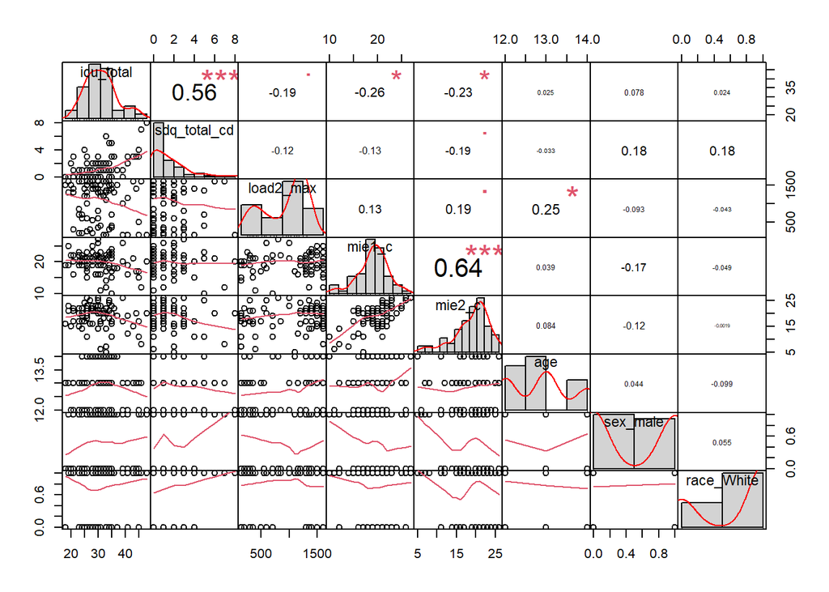

```r
PerformanceAnalytics::chart.Correlation(T2_dat %>% select("icu_total",
                                                          "sdq_total_cd",
                                                          "load2_max",
                                                          "mie1_c",
                                                          "mie2_c",
                                                          "age",
                                                          "sex_male",
                                                          "race_White"))
```

```r
data.frame(cor(T2_dat %>% select("icu_total",
                                 "sdq_total_cd",
                                 "load2_max",
                                 "mie1_c",
                                 "mie2_c",
                                 "age",
                                 "sex_male",
                                 "race_White"), method= "spearman"))
```

|  | icu_total | sdq_total_cd | load2_max | mie1_c | mie2_c | age | sex_male | race_White |
| --- | --- | --- | --- | --- | --- | --- | --- | --- |
| icu_total | 1.000000000 | 0.481437450 | -0.18206313 | -0.21615808 | -0.18133201 | 0.082413872 | 0.06883498 | 0.004009191 |
| sdq_total_cd | 0.481437450 | 1.000000000 | -0.12365208 | -0.03400351 | -0.09740453 | 0.007940741 | 0.10882302 | 0.165622244 |
| load2_max | -0.182063133 | -0.123652084 | 1.00000000 | 0.14422670 | 0.15481377 | 0.260275004 | -0.03830598 | -0.035679500 |
| mie1_c | -0.216158082 | -0.034003511 | 0.14422670 | 1.00000000 | 0.53863614 | 0.019589218 | -0.15640357 | -0.031648633 |
| mie2_c | -0.181332014 | -0.097404531 | 0.15481377 | 0.53863614 | 1.00000000 | 0.105817501 | -0.07854430 | 0.066015172 |
| age | 0.082413872 | 0.007940741 | 0.26027500 | 0.01958922 | 0.10581750 | 1.000000000 | 0.03225356 | -0.099154128 |
| sex_male | 0.068834977 | 0.108823021 | -0.03830598 | -0.15640357 | -0.07854430 | 0.032253564 | 1.00000000 | 0.055470020 |
| race_White | 0.004009191 | 0.165622244 | -0.03567950 | -0.03164863 | 0.06601517 | -0.099154128 | 0.05547002 | 1.000000000 |

# 3 Preliminary analyses

## 3.1 Assessing bias for those that are removed - T-tests

```r
set.seed(1982)
lapply(T2_dat[,c("mie2_complex",
                 "mie1_complex",
                 "icu_total" ,
                 "sex_male",
                 "age",
                 "race_White",
                 "anny2_diff",
                 "WAI_total",
                 "sdq_total_cd")],
       function(x) MKinfer::boot.t.test(x ~ T2_dat$bad_load_2, var.equal = FALSE))
```

```
## $mie2_complex
##
##  Bootstrapped Welch Two Sample t-test
##
## data:  x by T2_dat$bad_load_2
## bootstrapped p-value = 0.1902
## 95 percent bootstrap percentile confidence interval:
##  -0.4444444  3.2222222
##
## Results without bootstrap:
## t = 1.4243, df = 10.912, p-value = 0.1823
## alternative hypothesis: true difference in means is not equal to 0
## 95 percent confidence interval:
##  -0.7746265  3.6079598
## sample estimates:
## mean in group 0 mean in group 1
##        12.52778        11.11111
##
##
## $mie1_complex
##
##  Bootstrapped Welch Two Sample t-test
##
## data:  x by T2_dat$bad_load_2
## bootstrapped p-value = 0.2278
## 95 percent bootstrap percentile confidence interval:
##  -0.4166667  2.2083333
##
## Results without bootstrap:
## t = 1.2936, df = 10.925, p-value = 0.2225
## alternative hypothesis: true difference in means is not equal to 0
## 95 percent confidence interval:
##  -0.6443355  2.4776689
## sample estimates:
## mean in group 0 mean in group 1
##        13.02778        12.11111
##
##
## $icu_total
##
```

[output cut: 114 more lines]

```
##  Bootstrapped Welch Two Sample t-test
##
## data:  x by T2_dat$bad_load_2
## bootstrapped p-value = 0.6267
## 95 percent bootstrap percentile confidence interval:
##  -2.125694  1.013889
##
## Results without bootstrap:
## t = -0.35244, df = 8.8126, p-value = 0.7328
## alternative hypothesis: true difference in means is not equal to 0
## 95 percent confidence interval:
##  -2.273159  1.662048
## sample estimates:
## mean in group 0 mean in group 1
##        1.472222        1.777778
```

## 3.2 Assumption testing

### 3.2.1 Setting up dataframe for assumption testing

### 3.2.2 *Additivity - Multicollinerity*

```r
corrt <- cor(T2_dat_test1[,-c(1)])
symnum(corrt)
```

```
##              m2 m1 i sx_ ag r a2 W s__
## mie2_complex 1
## mie1_complex .  1
## icu_total       .  1
## sex_male             1
## age                      1
## race_White                  1
## anny2_diff                    1
## WAI_total                        1
## sdq_total_cd       .             . 1
## attr(,"legend")
## [1] 0 ' ' 0.3 '.' 0.6 ',' 0.8 '+' 0.9 '*' 0.95 'B' 1
```

> THere are no ‘+’, ’*‘, or ’B’ suggesting a high correlation betwen variables so these are fine.

### 3.2.3 *Normality of residuals*

```r
random <- rchisq(nrow(T2_dat_test1[,-c(1)]), 10)
  # creating a fake regression
    # remove the ID variable since you are regression the entire data set
fake <- lm(random~.,data=T2_dat_test1[,-c(1)])
  # creating studentized residuals
studentized <- rstudent(fake)
```

### 3.2.4 *Distribution of residuals*

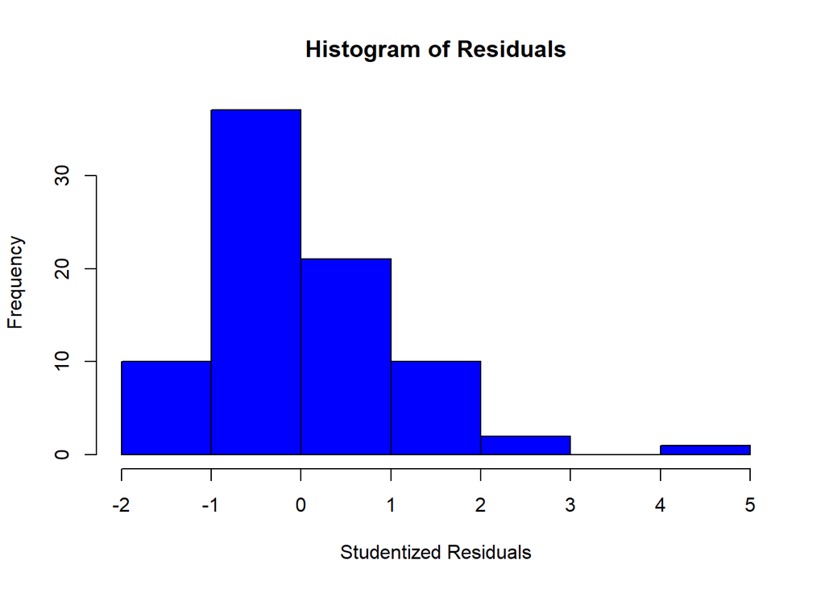

```r
hist(studentized,breaks = 8,
     main="Histogram of Residuals",
     xlab="Studentized Residuals",
     border="black",
     col="blue")
```

> Mostly evenly distributed just a alight positive tail – let’s check the skewnes and kurtosis

```r
psych::describe(studentized)
```

|  | vars | n | mean | sd | median | trimmed | mad | min | max | range | skew | kurtosis | se |
| --- | --- | --- | --- | --- | --- | --- | --- | --- | --- | --- | --- | --- | --- |
| X1 | 1 | 81 | 0.007902222 | 1.032178 | -0.3189264 | -0.05922781 | 0.884589 | -1.729 | 4.041786 | 5.770786 | 0.9201047 | 1.439511 | 0.1146864 |

> This looks okay - only a slight positive tail but the distribution is relativley intact. No significant concerns.

### 3.2.5 *Mean of residuals close to 0*

```r
mean(fake$residuals) ## mean is close to 0
```

```
## [1] -3.584988e-16
```

> Mean is very close to 0

### 3.2.6 *Residual plot*

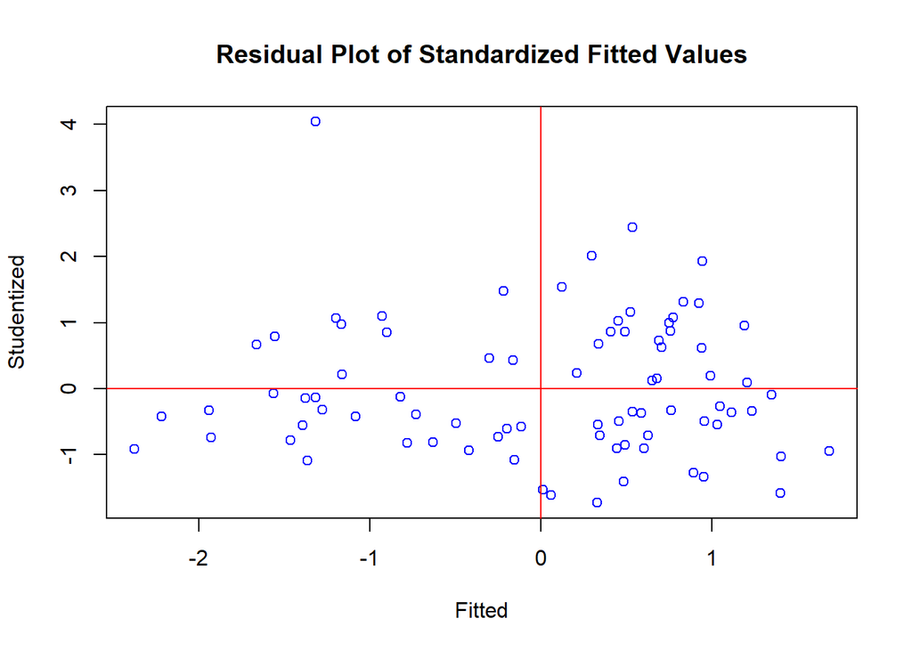

```r
  # resigual plot
    # creating a z-scored fitted variable vector for interpretation
fitted <- scale(fake$fitted.values)
  # residual plot -
plot(fitted, studentized,
     main="Residual Plot of Standardized Fitted Values",
     xlab="Fitted",
     ylab = "Studentized",
     col="blue")
abline(0,0, col="red")
abline(v=0, col="red")
```

> Data look evenly dispursed across the figure in each sector

### 3.2.7 *Autocorrelation*

```r
durbinWatsonTest(fake) # autocorrelation of residuals
```

```
##  lag Autocorrelation D-W Statistic p-value
##    1      -0.1560047      2.266596   0.178
##  Alternative hypothesis: rho != 0
```

> Test is not statistically significant (p>.05) and the statistic is close to 2

### 3.2.8 *Multicollinearity of predictors and controls*

```r
library(olsrr)
ols_vif_tol(assumpt<-lm(random ~ mie2_complex + mie1_complex + icu_total + sex_male + age + race_White + anny2_diff + WAI_total, data = T2_dat))
```

| Variables | Tolerance | VIF |
| --- | --- | --- |
| mie2_complex | 0.6469581 | 1.545695 |
| mie1_complex | 0.5961197 | 1.677515 |
| icu_total | 0.8014288 | 1.247771 |
| sex_male | 0.9439069 | 1.059427 |
| age | 0.9452747 | 1.057894 |
| race_White | 0.9198909 | 1.087085 |
| anny2_diff | 0.8060566 | 1.240608 |
| WAI_total | 0.9128657 | 1.095451 |

> After including all variables that will be used as controls and predictors a only a small portion of each variable is filtered away meaning we do not have multicollinearity assumption met.- all VIF < 2.5 all tolerance is >=.5

# 4 Measures Reliability Alpha

## 4.1 ICU

```r
psych::alpha(T2_dat[,c(grepl( "ICU." , names( T2_dat ) ))])
```

```
## Some items ( ICU.19. ICU.23. ) were negatively correlated with the total scale and
## probably should be reversed.
## To do this, run the function again with the 'check.keys=TRUE' option
```

```
##
## Reliability analysis
## Call: psych::alpha(x = T2_dat[, c(grepl("ICU.", names(T2_dat)))])
##
##   raw_alpha std.alpha G6(smc) average_r S/N   ase mean  sd median_r
##       0.77      0.79    0.88      0.13 3.7 0.035  1.4 0.3     0.13
##
##  lower alpha upper     95% confidence boundaries
## 0.7 0.77 0.84
##
##  Reliability if an item is dropped:
##         raw_alpha std.alpha G6(smc) average_r S/N alpha se var.r med.r
## ICU.1.       0.75      0.77    0.87      0.13 3.3    0.038 0.035  0.12
## ICU.3.       0.74      0.76    0.87      0.12 3.2    0.040 0.034  0.12
## ICU.5.       0.75      0.77    0.87      0.13 3.4    0.038 0.037  0.12
## ICU.8.       0.75      0.77    0.87      0.12 3.3    0.039 0.035  0.12
## ICU.13.      0.76      0.78    0.87      0.13 3.5    0.037 0.037  0.13
## ICU.15.      0.76      0.77    0.87      0.13 3.4    0.037 0.034  0.12
## ICU.16.      0.75      0.76    0.86      0.12 3.2    0.039 0.034  0.12
## ICU.17.      0.76      0.77    0.87      0.13 3.4    0.037 0.036  0.13
## ICU.24.      0.75      0.77    0.87      0.13 3.4    0.038 0.035  0.12
## ICU.2        0.76      0.78    0.87      0.13 3.5    0.036 0.037  0.13
## ICU.4        0.76      0.78    0.87      0.13 3.5    0.036 0.036  0.12
## ICU.6        0.78      0.79    0.88      0.14 3.8    0.034 0.035  0.13
## ICU.7        0.77      0.78    0.87      0.14 3.6    0.035 0.037  0.13
## ICU.9        0.76      0.77    0.87      0.13 3.4    0.037 0.036  0.12
## ICU.10       0.78      0.79    0.88      0.14 3.8    0.033 0.038  0.14
## ICU.11       0.76      0.78    0.87      0.13 3.5    0.036 0.035  0.12
## ICU.12       0.76      0.78    0.87      0.13 3.5    0.036 0.037  0.13
## ICU.14.      0.78      0.79    0.88      0.14 3.9    0.033 0.035  0.14
## ICU.18       0.78      0.79    0.88      0.14 3.8    0.034 0.037  0.14
## ICU.19.      0.79      0.80    0.88      0.15 4.0    0.032 0.035  0.14
## ICU.20       0.76      0.78    0.87      0.13 3.5    0.036 0.037  0.12
## ICU.21       0.77      0.78    0.87      0.13 3.6    0.035 0.037  0.13
## ICU.22       0.76      0.77    0.87      0.13 3.4    0.037 0.037  0.12
## ICU.23.      0.80      0.81    0.89      0.16 4.4    0.030 0.029  0.14
##
##  Item statistics
##          n  raw.r std.r  r.cor r.drop mean   sd
## ICU.1.  81  0.617  0.61  0.601  0.533 1.07 0.88
```

[output cut: 35 more lines]

```
## ICU.2   0.00 0.26 0.58 0.06 0.10    0
## ICU.4   0.00 0.89 0.10 0.00 0.01    0
## ICU.6   0.00 0.23 0.47 0.25 0.05    0
## ICU.7   0.00 0.59 0.30 0.07 0.04    0
## ICU.9   0.00 0.67 0.26 0.06 0.01    0
## ICU.10  0.00 0.15 0.52 0.20 0.14    0
## ICU.11  0.00 0.74 0.23 0.02 0.00    0
## ICU.12  0.00 0.81 0.17 0.01 0.00    0
## ICU.14. 0.00 0.22 0.46 0.25 0.07    0
## ICU.18  0.00 0.72 0.25 0.01 0.02    0
## ICU.19. 0.00 0.21 0.58 0.12 0.09    0
## ICU.20  0.00 0.67 0.30 0.01 0.02    0
## ICU.21  0.00 0.79 0.16 0.04 0.01    0
## ICU.22  0.00 0.25 0.57 0.14 0.05    0
## ICU.23. 0.00 0.04 0.33 0.38 0.25    0
```

```r
psych::describe(T2_dat$icu_total)
```

|  | vars | n | mean | sd | median | trimmed | mad | min | max | range | skew | kurtosis | se |
| --- | --- | --- | --- | --- | --- | --- | --- | --- | --- | --- | --- | --- | --- |
| X1 | 1 | 81 | 30.23457 | 6.682574 | 30 | 29.75385 | 5.9304 | 18 | 48 | 30 | 0.5699084 | -0.03718048 | 0.7425082 |

## 4.2 SDQ - CD

```r
psych::alpha(T2_dat[,c(grepl( "sdq\\d+" , names( T2_dat ) ))])
```

```
##
## Reliability analysis
## Call: psych::alpha(x = T2_dat[, c(grepl("sdq\\d+", names(T2_dat)))])
##
##   raw_alpha std.alpha G6(smc) average_r S/N   ase mean   sd median_r
##       0.66      0.71    0.69      0.33 2.4 0.059  0.3 0.34     0.37
##
##  lower alpha upper     95% confidence boundaries
## 0.55 0.66 0.78
##
##  Reliability if an item is dropped:
##       raw_alpha std.alpha G6(smc) average_r S/N alpha se  var.r med.r
## sdq5       0.57      0.64    0.62      0.31 1.8    0.079 0.0377  0.26
## sdq12      0.60      0.65    0.62      0.31 1.8    0.073 0.0371  0.28
## sdq7       0.72      0.76    0.72      0.45 3.2    0.047 0.0066  0.44
## sdq18      0.57      0.64    0.60      0.31 1.8    0.075 0.0260  0.29
## sdq22      0.57      0.59    0.54      0.27 1.4    0.078 0.0169  0.26
##
##  Item statistics
##        n raw.r std.r r.cor r.drop  mean   sd
## sdq5  81  0.75  0.71  0.61   0.49 0.457 0.65
## sdq12 81  0.64  0.70  0.59   0.48 0.136 0.38
## sdq7  81  0.53  0.47  0.23   0.20 0.556 0.61
## sdq18 81  0.72  0.72  0.64   0.48 0.259 0.57
## sdq22 81  0.73  0.79  0.76   0.62 0.099 0.34
##
## Non missing response frequency for each item
##          0    1    2 miss
## sdq5  0.63 0.28 0.09    0
## sdq12 0.88 0.11 0.01    0
## sdq7  0.51 0.43 0.06    0
## sdq18 0.80 0.14 0.06    0
## sdq22 0.91 0.07 0.01    0
```

```r
psych::describe(T2_dat$sdq_total_cd)
```

|  | vars | n | mean | sd | median | trimmed | mad | min | max | range | skew | kurtosis | se |
| --- | --- | --- | --- | --- | --- | --- | --- | --- | --- | --- | --- | --- | --- |
| X1 | 1 | 81 | 1.506173 | 1.711165 | 1 | 1.2 | 1.4826 | 0 | 8 | 8 | 1.534542 | 2.489996 | 0.1901295 |

## 4.3 RMET ToM reliability

```r
b<-psych::omega(mie_it1[-c(which(T2_dat$bad_load_2==1)),],
                poly=TRUE,plot=FALSE,check.keys=TRUE)$omega.tot
b1<-psych::omega(mie_it1[-c(which(T2_dat$bad_load_2==1)),
                         c(1,2,4,6,7,17,19,21,25,26,28)],
                 poly=TRUE,plot=FALSE,check.keys=TRUE)$omega.tot
b2<-psych::omega(mie_it1[-c(which(T2_dat$bad_load_2==1)),
                         c(3,5,8,9,10,11,12,13,14,15,16,18,20,22,23,24,27)],
                 poly=TRUE,plot=FALSE,check.keys=TRUE)$omega.tot

b3<-psych::omega(mie_it2[-c(which(T2_dat$bad_load_2==1)),],
                 poly=TRUE,plot=FALSE,check.keys=TRUE)$omega.tot
b4<-psych::omega(mie_it2[-c(which(T2_dat$bad_load_2==1)),
                         c(1,2,4,6,7,17,19,21,25,26,28)],
                 poly=TRUE,plot=FALSE,check.keys=TRUE)$omega.tot
b5<-psych::omega(mie_it2[-c(which(T2_dat$bad_load_2==1)),
                         c(3,5,8,9,10,11,12,13,14,15,16,18,20,22,23,24,27)],
                 poly=TRUE,plot=FALSE,check.keys=TRUE)$omega.tot


cbind(rbind(data.frame(T1_Total=b,row.names = "Omega - ToM"),
            data.frame(T1_Total=round(b,2),row.names = "Omega - ToM rounded")),
      rbind(data.frame(T1_Basic=b1,row.names = "Omega - ToM"),
            data.frame(T1_Basic=round(b1,2),row.names = "Omega - ToM rounded")),
      rbind(data.frame(T1_Complex=b2,row.names = "Omega - ToM"),
            data.frame(T1_Complex=round(b2,2),row.names = "Omega - ToM rounded")),
      rbind(data.frame(T2_Total=b3,row.names = "Omega - ToM"),
            data.frame(T2_Total=round(b3,2),row.names = "Omega - ToM rounded")),
      rbind(data.frame(T2_Basic=b4,row.names = "Omega - ToM"),
            data.frame(T2_Basic=round(b4,2),row.names = "Omega - ToM rounded")),
      rbind(data.frame(T2_Complex=b5,row.names = "Omega - ToM"),
            data.frame(T2_Complex=round(b5,2),row.names = "Omega - ToM rounded")))
```

|  | T1_Total | T1_Basic | T1_Complex | T2_Total | T2_Basic | T2_Complex |
| --- | --- | --- | --- | --- | --- | --- |
| Omega - ToM | 0.772055 | 0.7364012 | 0.782455 | 0.8417632 | 0.7702047 | 0.83395 |
| Omega - ToM rounded | 0.770000 | 0.7400000 | 0.780000 | 0.8400000 | 0.7700000 | 0.83000 |

# 5 Mind in the eyes performance

## 5.1 For overall ToM

```r
library(lavaan)
mie<-'
mie1_c~icu_total+
        sex_male +
        age +
        race_White +
        sdq_total_cd +
        bad_resp2
'
mie_sem<-sem(mie,estimator='ML',data=T2_dat)
summary(mie_sem, rsquare=TRUE,standardized=TRUE, nd=4)
```

```
## lavaan 0.6-9 ended normally after 38 iterations
##
##   Estimator                                             ML
##   Optimization method                               NLMINB
##   Number of model parameters                             7
##
##   Number of observations                                81
##
## Model Test User Model:
##
##   Test statistic                                    0.0000
##   Degrees of freedom                                     0
##
## Parameter Estimates:
##
##   Standard errors                                 Standard
##   Information                                     Expected
##   Information saturated (h1) model              Structured
##
## Regressions:
##                     Estimate   Std.Err   z-value   P(>|z|)    Std.lv   Std.all
##   mie1_c ~
##     icu_total        -0.1478    0.0631   -2.3443    0.0191   -0.1478   -0.3008
##     sex_male         -1.0699    0.6991   -1.5304    0.1259   -1.0699   -0.1638
##     age               0.1950    0.4585    0.4252    0.6707    0.1950    0.0450
##     race_White       -0.3039    0.7611   -0.3993    0.6896   -0.3039   -0.0430
##     sdq_total_cd      0.1248    0.2518    0.4959    0.6200    0.1248    0.0651
##     bad_resp2        -0.9875    0.8976   -1.1003    0.2712   -0.9875   -0.1175
##
## Variances:
##                     Estimate   Std.Err   z-value   P(>|z|)    Std.lv   Std.all
##    .mie1_c            9.4997    1.4927    6.3640    0.0000    9.4997    0.8920
##
## R-Square:
##                     Estimate
##     mie1_c            0.1080
```

### 5.1.1 Bootstrapped CIs

```r
set.seed(1982)
mie_semb<-sem(mie,estimator='ML',data=T2_dat[-c(T2_dat$bad_resp2),], se="bootstrap", bootstrap=5000)
parameterEstimates(mie_semb, boot.ci.type = "bca.simple")
```

| lhs | op | rhs | est | se | z | pvalue | ci.lower | ci.upper |
| --- | --- | --- | --- | --- | --- | --- | --- | --- |
| mie1_c | ~ | icu_total | -0.14843299 | 0.06528381 | -2.2736569 | 2.298662e-02 | -0.28312737 | -0.02575539 |
| mie1_c | ~ | sex_male | -1.05383601 | 0.73972458 | -1.4246329 | 1.542633e-01 | -2.54818030 | 0.38891936 |
| mie1_c | ~ | age | 0.19440062 | 0.50333621 | 0.3862242 | 6.993306e-01 | -0.82103538 | 1.15083916 |
| mie1_c | ~ | race_White | -0.33249062 | 0.80534466 | -0.4128551 | 6.797128e-01 | -1.95405467 | 1.20689714 |
| mie1_c | ~ | sdq_total_cd | 0.12782199 | 0.32370812 | 0.3948680 | 6.929403e-01 | -0.55426275 | 0.71885748 |
| mie1_c | ~ | bad_resp2 | -0.99659752 | 0.91658838 | -1.0872901 | 2.769086e-01 | -2.74576157 | 0.81348134 |
| mie1_c | ~~ | mie1_c | 9.61366165 | 1.64466318 | 5.8453681 | 5.054494e-09 | 7.29006747 | 14.45144976 |
| icu_total | ~~ | icu_total | 44.65609375 | 0.00000000 | NA | NA | 44.65609375 | 44.65609375 |
| icu_total | ~~ | sex_male | 0.26218750 | 0.00000000 | NA | NA | 0.26218750 | 0.26218750 |
| icu_total | ~~ | age | 0.12671875 | 0.00000000 | NA | NA | 0.12671875 | 0.12671875 |

[output cut: 18 more lines]

## 5.2 Basic and Complex

```r
library(lavaan)
mie<-'
mie1_complex + mie1_basic ~ icu_total +
                            sex_male +
                            age +
                            race_White  +
                            sdq_total_cd +
                            bad_resp2
'
mie_sem<-sem(mie,estimator='ML',data=T2_dat)
parameterestimates(mie_sem, rsquare=TRUE,standardized=TRUE)[37:38,]
```

|  | lhs | op | rhs | est | se | z | pvalue | ci.lower | ci.upper | std.lv | std.all | std.nox |
| --- | --- | --- | --- | --- | --- | --- | --- | --- | --- | --- | --- | --- |
| 37 | mie1_complex | r2 | mie1_complex | 0.1657357 | NA | NA | NA | NA | NA | NA | NA | NA |
| 38 | mie1_basic | r2 | mie1_basic | 0.0484026 | NA | NA | NA | NA | NA | NA | NA | NA |

### 5.2.1 Bootstrapped CIs

```r
set.seed(1982)
mie_semb<-sem(mie,estimator='ML',data=T2_dat, se="bootstrap", bootstrap=5000)
parameterEstimates(mie_semb,rsquare=TRUE,standardized=TRUE, boot.ci.type = "bca.simple")[1:12,]
```

|  | lhs | op | rhs | est | se | z | pvalue | ci.lower | ci.upper | std.lv | std.all | std.nox |
| --- | --- | --- | --- | --- | --- | --- | --- | --- | --- | --- | --- | --- |
| 1 | mie1_complex | ~ | icu_total | -1.478185e-01 | 0.04502442 | -3.2830732025 | 0.00102682 | -0.24115160 | -0.06101783 | -1.478185e-01 | -4.355150e-01 | -6.557781e-02 |
| 2 | mie1_complex | ~ | sex_male | -9.032700e-01 | 0.50938726 | -1.7732480854 | 0.07618761 | -1.94205356 | 0.07756399 | -9.032700e-01 | -2.002248e-01 | -4.007245e-01 |
| 3 | mie1_complex | ~ | age | 1.205246e-01 | 0.33725604 | 0.3573682857 | 0.72081612 | -0.52967405 | 0.78831790 | 1.205246e-01 | 4.029400e-02 | 5.346924e-02 |
| 4 | mie1_complex | ~ | race_White | -3.846642e-01 | 0.54479856 | -0.7060669113 | 0.48014653 | -1.50586189 | 0.66264581 | -3.846642e-01 | -7.882956e-02 | -1.706515e-01 |
| 5 | mie1_complex | ~ | sdq_total_cd | 3.248106e-01 | 0.19689656 | 1.6496511412 | 0.09901431 | -0.05993419 | 0.70977043 | 3.248106e-01 | 2.450490e-01 | 1.440982e-01 |
| 6 | mie1_complex | ~ | bad_resp2 | -4.038369e-01 | 0.56788974 | -0.7111184286 | 0.47701085 | -1.48188490 | 0.77211707 | -4.038369e-01 | -6.959320e-02 | -1.791572e-01 |
| 7 | mie1_basic | ~ | icu_total | -1.309362e-05 | 0.03638053 | -0.0003599075 | 0.99971284 | -0.07459484 | 0.06979126 | -1.309362e-05 | -4.723912e-05 | -7.113045e-06 |
| 8 | mie1_basic | ~ | sex_male | -1.666798e-01 | 0.39921913 | -0.4175144745 | 0.67630214 | -0.93449471 | 0.64642041 | -1.666798e-01 | -4.524291e-02 | -9.054795e-02 |
| 9 | mie1_basic | ~ | age | 7.443539e-02 | 0.29210973 | 0.2548199510 | 0.79886217 | -0.51495827 | 0.61309543 | 7.443539e-02 | 3.047275e-02 | 4.043665e-02 |
| 10 | mie1_basic | ~ | race_White | 8.072008e-02 | 0.45932403 | 0.1757366780 | 0.86050082 | -0.80708129 | 1.01170261 | 8.072008e-02 | 2.025612e-02 | 4.385078e-02 |

[output cut: 2 more lines]

## 5.3 Subscale analyses

> here we examine if any single subscale is driving the association observed.

```r
library(lavaan)
mie2<-'
mie1_complex + mie1_basic ~ icu_callousness +
                            icu_unemotional +
                            icu_uncaring +
                            sex_male +
                            age +
                            race_White  +
                            sdq_total_cd +
                            bad_resp2
'
mie_sem2<-sem(mie2,estimator='ML',data=T2_dat)
parameterestimates(mie_sem2, rsquare=TRUE,standardized=TRUE)[c(1:16,56:57),]
```

|  | lhs | op | rhs | est | se | z | pvalue | ci.lower | ci.upper | std.lv | std.all | std.nox |
| --- | --- | --- | --- | --- | --- | --- | --- | --- | --- | --- | --- | --- |
| 1 | mie1_complex | ~ | icu_callousness | -0.212249773 | 0.09370643 | -2.26505027 | 0.02350959 | -0.39591100 | -0.02858855 | -0.212249773 | -0.270938277 | -0.09416196 |
| 2 | mie1_complex | ~ | icu_unemotional | -0.046747645 | 0.14040528 | -0.33294792 | 0.73917360 | -0.32193693 | 0.22844164 | -0.046747645 | -0.039368158 | -0.02073901 |
| 3 | mie1_complex | ~ | icu_uncaring | -0.136221409 | 0.08372334 | -1.62704225 | 0.10372813 | -0.30031614 | 0.02787332 | -0.136221409 | -0.215919266 | -0.06043293 |
| 4 | mie1_complex | ~ | sex_male | -0.889279681 | 0.46517699 | -1.91170177 | 0.05591446 | -1.80100983 | 0.02245047 | -0.889279681 | -0.197123575 | -0.39451783 |
| 5 | mie1_complex | ~ | age | 0.123717734 | 0.30625135 | 0.40397450 | 0.68623147 | -0.47652387 | 0.72395934 | 0.123717734 | 0.041361533 | 0.05488583 |
| 6 | mie1_complex | ~ | race_White | -0.390834037 | 0.51156305 | -0.76399974 | 0.44486740 | -1.39347919 | 0.61181112 | -0.390834037 | -0.080093938 | -0.17338864 |
| 7 | mie1_complex | ~ | sdq_total_cd | 0.311169877 | 0.17073367 | 1.82254551 | 0.06837226 | -0.02346196 | 0.64580171 | 0.311169877 | 0.234757915 | 0.13804663 |
| 8 | mie1_complex | ~ | bad_resp2 | -0.331357075 | 0.60264829 | -0.54983492 | 0.58243260 | -1.51252601 | 0.84981186 | -0.331357075 | -0.057102759 | -0.14700243 |
| 9 | mie1_basic | ~ | icu_callousness | 0.047891675 | 0.08179250 | 0.58552648 | 0.55819377 | -0.11241868 | 0.20820203 | 0.047891675 | 0.074860140 | 0.02601691 |
| 10 | mie1_basic | ~ | icu_unemotional | -0.086117690 | 0.12255401 | -0.70269173 | 0.48224788 | -0.32631914 | 0.15408376 | -0.086117690 | -0.088806593 | -0.04678301 |

[output cut: 8 more lines]

## 5.4 Figure

```r
## still editing this one - need to get the labels right

icu<-resid(lm(icu_total ~
            sex_male +
            age +
            race_White +
            sdq_total_cd +
            bad_resp2, data=T2_dat))

comp<-resid(lm(mie1_complex ~
            sex_male +
            age +
            race_White +
            sdq_total_cd +
            bad_resp2, data=T2_dat))

basic<-resid(lm(mie1_basic ~
            sex_male +
            age +
            race_White +
            sdq_total_cd +
            bad_resp2, data=T2_dat))

dat<-data.frame(icu,comp,basic)

library(latex2exp)
library(ggpubr)
my_y_titlea <- expression(paste(bold(underline("Complex")), " Affective Theory of Mind - T1"))
my_y_titleb <- expression(paste(bold(underline("Basic")), " Affective Theory of Mind - T1"))
a<-ggplot(dat,aes(x=icu,y=comp)) +
  geom_smooth(method="lm",col="black") +
  geom_point(color="dark grey")+
  theme_minimal()+
  scale_x_continuous("Callous-Unemotional Traits",n.breaks = 5, labels = c("20","25","30","35","40", "45", "50")) + #,n.breaks = 5, labels = c("20","25","30","35","40", "45", "50")
  scale_y_continuous(my_y_titlea, limits = c(-4,3), n.breaks = 4, labels = c("7.5","10","12.5","15","17.5")) + #, n.breaks = 4, labels = c("7.5","10","12.5","15","17.5")
  labs(title = TeX("$\\;$  $\\textit{R^2} = $\\textit{0.166^*}"))+
  theme(axis.text=element_text(size=rel(1.1)),axis.title=element_text(size=17),title =element_text(size=17))
#+ylim(-4,3)
# + scale_y_continuous(my_y_titlea,n.breaks =  5, labels = c("200","600","1000","1400","1800")

b<-ggplot(dat,aes(x=icu,y=basic)) +
  geom_smooth(method="lm",col="black") +
  geom_point(color="dark grey")+
  theme_minimal()+
  scale_x_continuous("Callous-Unemotional Traits",n.breaks = 5, labels = c("20","25","30","35","40", "45", "50")) + # n.breaks = 5, labels = c("20","25","30","35","40", "45", "50")
  scale_y_continuous(my_y_titleb,limits = c(-4,3),n.breaks = 4, labels = c("1","3","5","7","9")) + #,n.breaks = 4, labels = c("1","3","5","7","9")
  labs(title = TeX("$\\;$ $\\textit{R^2} = $\\textit{0.048^n^s}"))+
  theme(axis.text=element_text(size=rel(1.1)),axis.title=element_text(size=17),title =element_text(size=17))
```

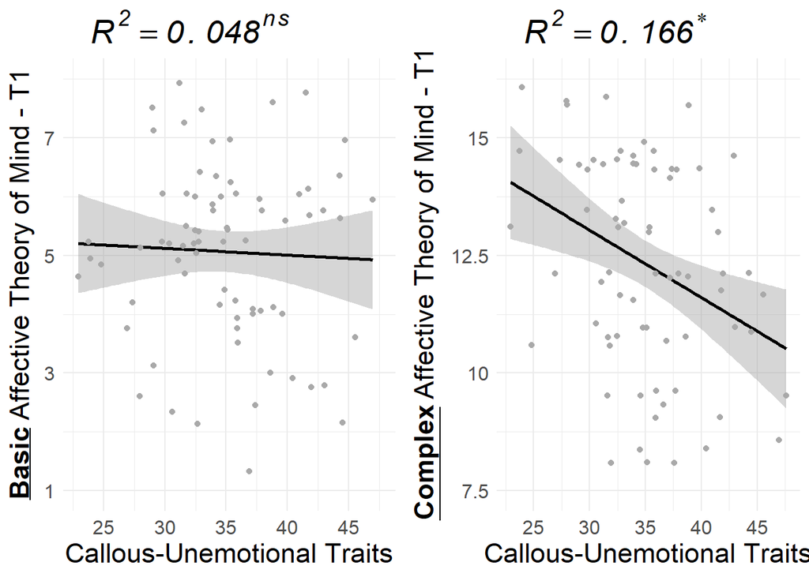

```r
d<-ggarrange(b,a, ncol=2,nrow=1)

d
```

```r
## 550 x 550 or 5.5 in "in" units
#ggsave(path = "C:\\Users\\wintersd\\OneDrive - The University of Colorado Denver\\DPRG main project\\Analyses and Data\\full_data_87\\1_Paper-1", plot=d, width = 5.5, height = 5.5, filename = "basic-comp_aff.tiff", device='tiff', dpi=700, limitsize = FALSE)
```